# xG model: single-hidden-layer neural network

## 0. Preparation

The **tidyverse** package provides a collection of tools for working with and visualising data. In this analysis, we use functions such as `read_csv()`, `dplyr` functions for data manipulation, and `ggplot2` for creating plots.

The **nnet** package allows us to fit the neural network model used later in this analysis.

We use `set.seed(2026)` to fix R’s random-number generator. This makes operations that depend on random numbers, such as the initialisation of the neural network, reproducible so that we obtain the same results when the analysis is rerun.

The packages `tidyverse` and `nnet` are installed automatically if they are missing, so no manual set-up is needed. The first run can take a few minutes if `tidyverse` has to be installed, and it needs an internet connection. If the installation fails, the document stops with a message naming the missing packages, which can then be installed by hand with `install.packages()`. Knitting also requires the `rmarkdown` and `knitr` packages, which RStudio provides.

The shot data is read from the `data` folder of the group’s GitHub repository. If a copy of the CSV file is found next to this document (or in a `data` folder beside it), that local copy is used instead, so the document also runs offline. An internet connection is therefore only needed the first time, if no local copy is present. The bibliography file is handled in the same way: a local copy is used if found, otherwise it is downloaded from the `dylan` folder of the repository. Figures and prediction files are saved in an `outputs` folder, which is created next to this document.

```r
# Install any missing packages automatically, then load them.
# (rmarkdown and knitr are needed to knit this document, but RStudio provides them.)
pkgs <- c("tidyverse", "nnet")

is_installed <- function(p) requireNamespace(p, quietly = TRUE)
missing_pkgs <- pkgs[!vapply(pkgs, is_installed, logical(1))]

if (length(missing_pkgs)) {
  message("Installing missing packages: ", paste(missing_pkgs, collapse = ", "))

  # Use the personal library if there is one, so no permission prompt is needed
  user_lib <- Sys.getenv("R_LIBS_USER")
  if (nzchar(user_lib)) {
    dir.create(user_lib, recursive = TRUE, showWarnings = FALSE)
    .libPaths(c(user_lib, .libPaths()))
  }

  # Name the CRAN mirror explicitly, because none is set when knitting non-interactively
  install.packages(missing_pkgs, repos = "https://cloud.r-project.org")

  still_missing <- pkgs[!vapply(pkgs, is_installed, logical(1))]
  if (length(still_missing)) {
    stop("Could not install: ", paste(still_missing, collapse = ", "),
         ". Please install them manually, e.g. install.packages(c(",
         paste0('"', still_missing, '"', collapse = ", "), ")).")
  }
}

library(tidyverse)
library(nnet)

# Set the random seed so that results are reproducible
set.seed(2026)

# Data: use a local copy if one is found, otherwise download from GitHub
raw_url <- "https://raw.githubusercontent.com/donny31415/Group-Sprint-1/main/data/shots_cleaned.csv"
local_candidates <- c("shots_cleaned.csv",
                      "data/shots_cleaned.csv",
                      "../data/shots_cleaned.csv")
data_path <- local_candidates[file.exists(local_candidates)][1]
if (is.na(data_path)) data_path <- raw_url

# Stop with a clear message if the data cannot be read
invisible(tryCatch(
  read_csv(data_path, n_max = 5, show_col_types = FALSE),
  error = function(e) stop("Cannot read the data from: ", data_path,
                           "\nCheck your internet connection and that the file exists.")
))
cat("Reading data from:", data_path, "\n")
```

```
## Reading data from: shots_cleaned.csv
```

```r
# Bibliography: use the most complete copy of bibliography.bib that can be found
# (local copies first, then GitHub), so an out-of-date copy is never used by mistake.
bib_url <- "https://raw.githubusercontent.com/donny31415/Group-Sprint-1/main/dylan/bibliography.bib"
count_entries <- function(lines) sum(grepl("^@[A-Za-z]+\\{", lines))

bib_local <- c("bibliography.bib", "../dylan/bibliography.bib",
               "dylan/bibliography.bib", "../bibliography.bib")
bib_local <- bib_local[file.exists(bib_local)]
bib_lines <- lapply(bib_local, readLines, warn = FALSE)
bib_n     <- vapply(bib_lines, count_entries, numeric(1))

best_lines <- NULL
best_n     <- 0
if (length(bib_n)) {
  j <- which.max(bib_n)
  best_lines <- bib_lines[[j]]
  best_n     <- bib_n[j]
}

remote <- tryCatch(readLines(bib_url, warn = FALSE),
                   error = function(e) character(), warning = function(w) character())
if (count_entries(remote) > best_n) {
  best_lines <- remote
  best_n     <- count_entries(remote)
}

if (is.null(best_lines)) {
  warning("Could not find or download bibliography.bib; citations will not render.")
} else {
  writeLines(best_lines, "bibliography.bib")
  cat("Bibliography entries available:", best_n, "\n")
}
```

```
## Bibliography entries available: 13
```

```r
# Outputs (figures and prediction files) are saved here
dir.create("outputs", showWarnings = FALSE)
```

## 1. Data and features

The `read_csv()` function loads the shot data (the number of shots and the overall goal rate are printed below the code). Each shot is identified using `row_id`, which corresponds to the row number in the original CSV file. This allows predictions produced in R and Python to be matched exactly.

The `xg` column contains Understat’s own expected goals (xG) estimate. It is therefore **never used as an input feature** for the neural network and is instead retained only as a benchmark against which the model’s predictions can be compared.

We then create a new column, `distance`, which calculates the distance from the goal using Pythagoras’ theorem, assuming the centre of the goal is located at $x = 120,\ y = 40$.

We then separate the columns according to their roles:

- **Target:** `result` — the outcome of the shot, where 1 represents a goal and 0 represents no goal.
- **Excluded:** `xg` is used only as a benchmark. `team` and `season` are excluded because they are not relevant to the prediction, while `row_id` is an identifier rather than a predictive feature.
- **Features:** The remaining 35 columns (including the derived `distance`) are used as the network’s 35 input variables.
- **Continuous variables:** `x`, `y`, `angle_to_goal`, `distance`, `minute`, and the score-related variables are rescaled before being supplied to the neural network, since neural networks train more effectively using numerical inputs on similar scales.

```r
shots <- read_csv(data_path, show_col_types = FALSE) %>%
  mutate(row_id = row_number(),
         distance = sqrt((120 - x)^2 + (40 - y)^2))  # goal at x = 120, y = 40

drop_cols <- c("xg", "result", "team", "season", "row_id")
feature_cols <- setdiff(names(shots), drop_cols)
continuous_cols <- c("x", "y", "angle_to_goal", "distance", "minute",
                     "team_goals_before", "opp_goals_before", "score_diff")

cat("Shots:", nrow(shots), " Goal rate:", round(mean(shots$result), 4), "\n")
```

```
## Shots: 50798  Goal rate: 0.1088
```

```r
cat("Features used:", length(feature_cols), "\n")
```

```
## Features used: 35
```

## 2. Train / validation / test split (by season)

The data is split by season rather than randomly. Seasons 2021/22–2023/24 are used for training, 2024/25 is used for validation, and 2025/26 is used for testing. This is the same test set used in the group comparison, so that every model is scored on the same shots. Any shots from the partial 2026/27 season in the data file are not used. The number of shots in each set is printed below the split code.

Splitting the data chronologically helps reduce temporal **data leakage** and better reflects how the model would be used in practice. The model is trained using historical shots, tuned using a subsequent season, and finally evaluated on a later season that was not available during model development. This also ensures that entire seasons are kept within a single dataset.

The `scale_fit` function calculates and stores the mean and standard deviation of each continuous input using **the training data only**. These training-set values are then used to standardise the continuous variables in the training, validation, and test sets. Using only the training data to calculate these values prevents information from the validation or test sets from influencing the model-development process.

The `to_matrix` function applies this standardisation by subtracting the training mean from each value and dividing by the training standard deviation. The standardisation is calculated as:

$$z = \frac{x-\mu_{\text{train}}}{\sigma_{\text{train}}}$$

where $x$ is the original value, $\mu_{\text{train}}$ is the mean of that variable calculated from the training data, and $\sigma_{\text{train}}$ is its standard deviation calculated from the training data. This is done for each feature and transforms the continuous variables to a comparable scale, with values centred around zero.

The function then converts the resulting features into a numeric matrix, which is the format required by `nnet`.

```r
train_seasons <- c("2021/22", "2022/23", "2023/24")
val_seasons   <- c("2024/25")
test_seasons  <- c("2025/26")  # same test season as the group comparison

train <- filter(shots, season %in% train_seasons)
val   <- filter(shots, season %in% val_seasons)
test  <- filter(shots, season %in% test_seasons)

c(train = nrow(train), val = nrow(val), test = nrow(test))
```

```
## train   val  test
## 29813  9844  9483
```

The training, validation and test sets contain 29,813, 9,844 and 9,483 shots respectively.

Continuous inputs are standardised using the mean and standard deviation calculated from the **training data only**. This is important for neural networks because inputs measured on very different scales can make optimisation less efficient. Standardising continuous input variables helps place predictors on comparable scales when fitting neural networks, as seen in Chapter 10.9.2 in [1].

```r
scale_fit <- function(df) {
  list(
    center = sapply(df[continuous_cols], mean),
    scale  = sapply(df[continuous_cols], sd)
  )
}

to_matrix <- function(df, sc) {
  X <- as.data.frame(df[feature_cols])

  Z <- sweep(
    as.matrix(df[continuous_cols]),
    2,
    sc$center,
    "-"
  )

  X[continuous_cols] <- sweep(
    Z,
    2,
    sc$scale,
    "/"
  )

  as.matrix(X)
}
```

## 3. Neural Network Model

A neural network was used to predict the probability that a shot would result in a goal. The model takes the 35 selected feature variables as inputs and uses one hidden layer to learn patterns in the data. The number of neurons in this hidden layer is controlled by the `size` parameter.

### Step 1: Define the model inputs

For each shot, the model receives 35 input features describing the shot and its context. These include variables such as shot location, distance to goal, angle to goal, match minute, and score-related information.

The feature columns and target variable are selected in R as follows:

```r
target_col <- "result"

# feature_cols was defined in Section 1: every column except
# xg, result, team, season and row_id (35 columns, including distance)
X_train <- to_matrix(train, scale_fit(train))
y_train <- train[[target_col]]
```

The `feature_cols` vector identifies the input variables, while `y_train` contains the actual outcomes used during training. The `to_matrix()` function prepares the input data in matrix form for the neural network.

### Step 2: Calculate the hidden-layer activations

Each neuron in the hidden layer receives all 35 input features. Each feature is multiplied by a learned weight, the weighted values are summed, and a bias is added. This is similar to that seen in Chapter 10.1 of [1] and the result is passed through a sigmoid activation function:

$$h_j=\sigma\left(\sum_{i=1}^{35}w_{ji}x_i+b_j\right)$$

where $x_i$ represents an input feature, $w_{ji}$ is the weight connecting input $i$ to hidden neuron $j$, and $b_j$ is the neuron’s bias. The sigmoid function is:

$$\sigma(z)=\frac{1}{1+e^{-z}}$$

It converts the weighted sum into an activation between 0 and 1. Each hidden neuron has its own weights and bias, allowing it to learn a different combination of the input features. For example, a neuron might learn a pattern involving shot distance and angle to goal, although individual neurons are not necessarily directly interpretable.

The hidden layer is specified through the `size` argument when fitting the model. For example, `size = 5` creates five neurons in a single hidden layer.

### Step 3: Calculate the predicted probability

This section is also inspired by Chapter 10.2 of [1]. The activations produced by the hidden layer are passed to an output neuron. This neuron combines the hidden-layer activations using a second set of learned weights and a bias, then applies the sigmoid function to produce the predicted probability of a goal:

$$\hat{p}=\sigma\left(\sum_{j=1}^{H}v_jh_j+b_o\right)$$

where $H$ is the number of hidden neurons, $h_j$ is the activation of hidden neuron $j$, $v_j$ is the weight connecting that neuron to the output, and $b_o$ is the output bias. The sigmoid function ensures that the predicted probability lies between 0 and 1.

The network is fitted using the `nnet` package through the `fit_nn()` function. The `size` parameter specifies the number of neurons in the hidden layer, `decay` controls weight decay to help reduce overfitting, and `maxit` sets the maximum number of optimisation iterations. The `entropy = TRUE` argument specifies the entropy-based error function for binary prediction, `MaxNWts` sets the maximum permitted number of weights, and `trace = FALSE` suppresses training progress output.

The model returns a probability rather than directly classifying a shot as a goal or a non-goal. For example, a predicted probability of 0.20 indicates that the model estimates a 20% chance of the shot resulting in a goal.

To reduce dependence on a single random initialisation, $K$ networks are fitted using different random seeds ($K = 2$ during hyperparameter tuning and $K = 5$ for the final model). Each network produces its own predicted probability, and these probabilities are averaged to obtain the final prediction:

$$\hat{p}_{\mathrm{ensemble}}=\frac{1}{K}\sum_{k=1}^{K}\hat{p}_k$$

where $\hat{p}_k$ is the predicted probability from network $k$ and $K$ is the number of networks. This averaging can reduce variation between individual model fits.

### Step 4: Measure the prediction error

During training, the predicted probability is compared with the actual outcome. The model uses binary cross-entropy, also known as log loss, to measure prediction error:

$$L=-\left[y\log(\hat{p})+(1-y)\log(1-\hat{p})\right]$$

Here, $y$ is the actual outcome and $\hat{p}$ is the predicted probability. Predictions that assign a high probability to the correct outcome receive a lower loss, while confident but incorrect predictions receive a higher loss.

For example, if a shot resulted in a goal ($y=1$) but the model predicted a probability of 0.20, the loss would be $-\log(0.20)$, approximately 1.61. The model aims to minimise the loss across the training data.

In the R implementation, `entropy = TRUE` tells `nnet` to use the entropy-based error function appropriate for binary outcomes.

### Step 5: Update the weights and biases

The network learns by adjusting its weights and biases to reduce the loss.

First, backpropagation as seen in Chapter 10.7.1 in [1] applies the chain rule to calculate how the loss changes with respect to each weight and bias. This determines how each parameter contributes to the prediction error.

The optimiser then uses this information to update the parameters. In this implementation, `nnet` uses a quasi-Newton optimisation method based on Broyden–Fletcher–Goldfarb–Shanno (BFGS), rather than simple gradient descent.

This process is repeated until the optimiser converges or reaches the maximum number of iterations specified by `maxit`. The weights and biases are learned from the training data; they are not manually specified.

### Step 6: Apply regularisation

The `decay` parameter controls weight decay, which penalises large weights and helps reduce overfitting. This encourages the network to learn patterns that generalise to unseen shots rather than relying too heavily on particular patterns in the training data.

For example, a model fitted with a weight-decay value of `0.01` applies regularisation during optimisation. Different values can be compared using the validation set to assess which setting gives better predictive performance.

The `MaxNWts` parameter sets an upper limit on the number of weights the model can use. It acts as a safeguard if the selected network architecture requires a large number of parameters.

### Step 7: Train multiple networks and average their predictions

To reduce dependence on a single random initialisation, $K$ networks are trained using different random seeds. Each network starts with its own random initial weights and independently learns its parameters from the training data.

The following functions implement this process:

```r
fit_nn <- function(X, y, size, decay, seeds = 1:3, maxit = 300) {
  lapply(seeds, function(s) {
    set.seed(s)

    nnet(
      x = X,
      y = y,
      size = size,
      decay = decay,
      maxit = maxit,
      entropy = TRUE,
      MaxNWts = 1e5,
      trace = FALSE
    )
  })
}

predict_nn <- function(models, X) {
  P <- do.call(
    cbind,
    lapply(models, function(m) {
      as.numeric(predict(m, X, type = "raw"))
    })
  )

  rowMeans(P)
}
```

The `fit_nn()` function fits one network for each seed and returns a list of trained models. Setting the seed makes each initialisation reproducible. The `predict_nn()` function obtains a predicted probability from each network and calculates the average probability for every shot.

The ensemble prediction is the average defined in Step 3. Averaging predictions from independently initialised networks can reduce variation between individual fits, although it does not guarantee improved performance.

### Step 8: Select and evaluate the model

The data is divided chronologically into training, validation, and test sets, as set out in Section 2.

The training set contains 29,813 shots and is used to estimate the network’s weights and biases. The validation set contains 9,844 shots and is used to compare model configurations, including the number of hidden neurons (`size`) and the weight-decay setting (`decay`). The test set contains 9,483 shots and is reserved for final evaluation.

This chronological split evaluates the model on a later season than those used for training, providing a more realistic assessment of how it may perform on future shots.

Overall, the neural network learns by repeatedly producing predictions, measuring their error, calculating how its parameters contribute to that error, and updating those parameters. The combination of nonlinear hidden-layer activations, regularisation, and averaging predictions from multiple networks allows the model to learn relationships between shot characteristics and the probability of scoring, as discussed in Chapter 10.7 of [1].

## 4. Performance metrics

An xG model has to be judged on three separate properties, and no single metric captures all of them: how accurate its probabilities are, how well it ranks goals above non-goals, and whether its probabilities mean what they claim to. Several metrics are therefore used, each chosen for something the others cannot show. Accuracy is not one of them. Goals make up only approximately 11% of shots, so a model that predicted “no goal” for every shot would be correct about 89% of the time while saying nothing about scoring probabilities.

Log loss is used first because it assesses the quality of the predicted probabilities themselves, which accuracy cannot do. It is a strictly proper scoring rule, meaning its expected value is minimised only when the predicted probabilities equal the true goal probabilities [2], so it rewards honest probability estimates rather than correct classifications. It is also the negative log-likelihood of a Bernoulli model, which is the quantity the network minimises during training, so validation and test log loss directly measure how well the fitted model generalises. Its main weakness is that it penalises confident incorrect predictions very heavily, so a small number of extreme errors can dominate the result [2].

The Brier score addresses that weakness by assessing the same property from a different angle. It is the mean squared difference between predicted probabilities and observed binary outcomes, and it originates from Brier’s (1950) work on verifying probabilistic forecasts [3]. Like log loss it is strictly proper [2], but it is bounded and penalises errors quadratically, so it is far less dominated by a handful of extreme predictions and describes the typical size of the error. Reporting both therefore shows whether conclusions depend on how heavily large errors are weighted. The Brier score has also been used in the xG literature to train and tune shot-probability models, with a constant-probability baseline as the reference point [4].

Log loss and the Brier score each summarise probability quality in a single number, but both mix two things together: how well the model separates goals from non-goals, and how well its probabilities are scaled. ROC-AUC isolates the first of these. It can be interpreted as the probability that a randomly chosen goal is assigned a higher predicted probability than a randomly chosen non-goal [5], and it does not require a single probability threshold to be chosen [6]. It is also unaffected by the low goal rate, because it compares goals with non-goals pair by pair. This is something the other metrics cannot show: a model’s ranking can be good or poor regardless of how its probabilities are scaled. The same property is its limitation. AUC depends only on the ordering of the predictions, so any monotone transformation of them leaves it unchanged, and a high ROC-AUC does not imply that the predicted probabilities are well calibrated [7], [8].

Calibration plots fill that gap. They compare predicted scoring probabilities with the observed frequency of goals across the range of predictions, so shots assigned an xG of 0.20 should result in goals about 20% of the time if the model is well calibrated [8]. Unlike the scalar metrics above, they show where in the probability range the model over- or underestimates. A model could be well calibrated on average yet overestimate high-xG shots, and no single score would reveal this. This matters for xG in particular, because xG values are summed to give team and match totals, so systematic bias in one range of probabilities accumulates into those totals.

Together the metrics cover complementary ground. Log loss and the Brier score assess the probabilities themselves under different weightings of error, ROC-AUC assesses ranking independently of scale, and calibration plots assess whether the probabilities are reliable and where they are not. A weakness that one metric hides is visible in another, which gives a more complete assessment of the model’s suitability for estimating expected goals.

The following functions calculate these metrics and prepare the data required for the calibration plots.

```r
log_loss <- function(y, p, eps = 1e-15) {
  p <- pmin(pmax(p, eps), 1 - eps)
  -mean(y * log(p) + (1 - y) * log(1 - p))
}
brier <- function(y, p) mean((y - p)^2)
auc <- function(y, p) {
  r <- rank(p); n1 <- sum(y == 1); n0 <- sum(y == 0)
  (sum(r[y == 1]) - n1 * (n1 + 1) / 2) / (n1 * n0)
}
evaluate <- function(y, p, name) {
  tibble(model = name, log_loss = log_loss(y, p), brier = brier(y, p), auc = auc(y, p))
}
calib_df <- function(y, p, name, bins = 10) {
  tibble(y = y, p = p) %>%
    mutate(bin = ntile(p, bins)) %>%
    group_by(bin) %>%
    summarise(mean_pred = mean(p), obs_rate = mean(y), .groups = "drop") %>%
    mutate(model = name)
}
```

## 5. Hyperparameter tuning on the validation season

Hyperparameter tuning is used to identify the model configuration that achieves the best predictive performance on unseen data. We learned about tuning hyperparameters in lectures, but a similar approach can be seen in Mead et al. (2023) [9]. The neural network is implemented using the `nnet` package in R [10]. Two hyperparameters are investigated in this model: the number of neurons in the hidden layer (`size`) and the weight-decay parameter (`decay`).

The `expand.grid()` function creates every combination of the selected hyperparameter values. Each combination is used to train a neural network on the training seasons (2021/22–2023/24), and its performance is evaluated using log loss on the validation season (2024/25). Two random initialisations are used for each configuration to reduce dependence on a single initialisation.

The continuous input features are standardised using means and standard deviations calculated from the training data. These same scaling values are then applied to the validation data, preventing information from the validation season from influencing the preprocessing.

The validation log loss for each configuration is recorded and displayed in a heatmap. Lower log loss indicates better predicted probabilities, with greater penalties for confident incorrect predictions. The configuration with the lowest validation log loss is selected using `which.min()`.

This tuning process illustrates the bias–variance trade-off. Increasing the number of hidden neurons gives the network greater flexibility to learn complex patterns, but may also increase the risk of overfitting. Increasing weight decay penalises larger weights, which can reduce overfitting but may also restrict the network’s ability to learn useful patterns. The validation data helps identify a balance between these effects.

The selected configuration is printed below. If it lies on the edge of the grid (for example the smallest hidden-unit value), it may be worth extending the grid. However, the selected configuration only identifies the best configuration among the combinations tested; it does not establish that it is the best possible configuration. The test set remains reserved for the final evaluation after model selection.

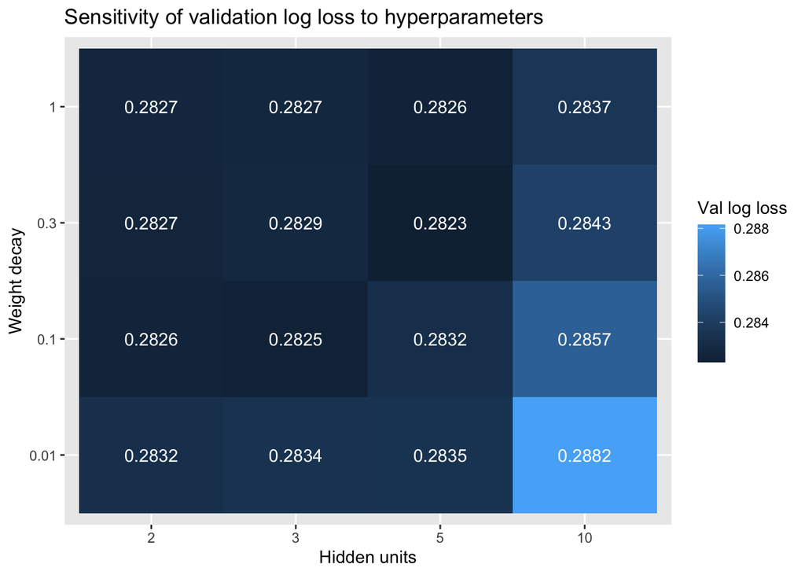

```r
sc_tr <- scale_fit(train)
X_tr  <- to_matrix(train, sc_tr)
X_val <- to_matrix(val, sc_tr)

grid <- expand.grid(size = c(2, 3, 5, 10), decay = c(0.01, 0.1, 0.3, 1))
grid$val_logloss <- NA_real_

for (i in seq_len(nrow(grid))) {
  m <- fit_nn(X_tr, train$result, grid$size[i], grid$decay[i], seeds = 1:2, maxit = 200)
  grid$val_logloss[i] <- log_loss(val$result, predict_nn(m, X_val))
}

ggplot(grid, aes(factor(size), factor(decay), fill = val_logloss)) +
  geom_tile() + geom_text(aes(label = round(val_logloss, 4)), colour = "white") +
  labs(x = "Hidden units", y = "Weight decay", fill = "Val log loss",
       title = "Sensitivity of validation log loss to hyperparameters")
```

```r
best <- grid[which.min(grid$val_logloss), ]
best
```

```
##    size decay val_logloss
## 11    5   0.3   0.2823068
```

The selected configuration is **5 hidden units** with **weight decay 0.3**.

## 6. Final model and test-set evaluation

After selecting the hyperparameters using validation log loss, the training and validation sets (seasons 2021/22–2024/25) are combined to provide more data for fitting the final model, matching the training data used for the other models in the group comparison. The scaler is refitted on this combined dataset, and the resulting scaling parameters are applied unchanged to the test set. The neural network is then trained using the selected hyperparameters and five different random seeds. Averaging the predicted probabilities from these five networks produces the final predictions, `p_nn`.

The test set has not been used for hyperparameter selection or model fitting, so it provides an independent evaluation of performance on a later season. The results table compares the neural network against Understat’s xG estimates, which serve as an existing benchmark, and a constant base-rate model that assigns every shot the same probability: the goal rate in the combined training and validation data.

Performance is assessed using log loss, Brier score and ROC-AUC. Log loss and Brier score evaluate the quality of the predicted probabilities, while ROC-AUC measures how well the model ranks goal-scoring shots above shots that do not result in goals. The calibration plot provides a further comparison between predicted probabilities and observed goal rates.

```r
# Combine training and validation data
trval <- bind_rows(train, val)

# Fit the scaler on the combined data and transform the inputs
sc_fin <- scale_fit(trval)
X_fin  <- to_matrix(trval, sc_fin)
X_te   <- to_matrix(test, sc_fin)

# Fit five networks using the selected hyperparameters
final_models <- fit_nn(
  X_fin, trval$result,
  best$size, best$decay,
  seeds = 1:5, maxit = 700
)

# Convergence check: 0 = converged, 1 = stopped at maxit
conv <- sapply(final_models, function(m) m$convergence)
conv
```

```
## [1] 0 0 0 0 0
```

```r
# Average the predicted probabilities
p_nn <- predict_nn(final_models, X_te)

# Compare performance on the test set
results <- bind_rows(
  evaluate(test$result, p_nn, "Neural network (R)"),
  evaluate(test$result, test$xg, "Understat xG (benchmark)"),
  evaluate(
    test$result,
    rep(mean(trval$result), nrow(test)),
    "Constant base rate"
  )
)

results
```

```
## # A tibble: 3 × 4
##   model                    log_loss  brier   auc
##   <chr>                       <dbl>  <dbl> <dbl>
## 1 Neural network (R)          0.277 0.0783 0.781
## 2 Understat xG (benchmark)    0.267 0.0756 0.801
## 3 Constant base rate          0.338 0.0947 0.5
```

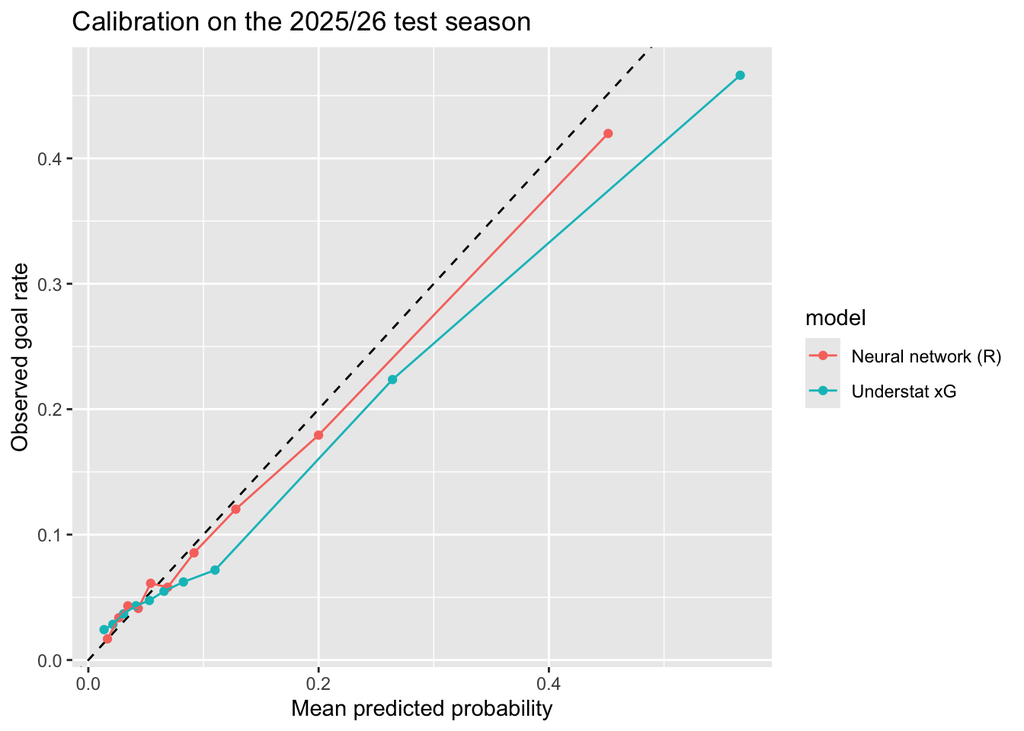

```r
# Compare calibration on the test set
bind_rows(
  calib_df(test$result, p_nn, "Neural network (R)"),
  calib_df(test$result, test$xg, "Understat xG")
) %>%
  ggplot(aes(mean_pred, obs_rate, colour = model)) +
  geom_abline(linetype = "dashed") +
  geom_point() +
  geom_line() +
  labs(
    x = "Mean predicted probability",
    y = "Observed goal rate",
    title = "Calibration on the 2025/26 test season"
  )
```

The convergence check returned zero for all five neural networks, indicating that each optimisation process met the convergence criterion before reaching the maximum of 700 iterations. This is important because it confirms that the final network parameters were not determined by prematurely stopping the optimisation algorithm. It therefore gives us greater confidence that the fitted weights have been adequately optimised and that the resulting predictions provide a fair basis for evaluating the model on the unseen test season. However, convergence alone does not guarantee a global optimum or good predictive performance, which must still be assessed using the test set metrics.

### Exporting predictions for the group comparison

The group comparison notebook joins the models’ files on `row_id` and expects the columns `row_id`, `nn_xg`, `goal` and `understat_xg`. R numbers rows from 1 whereas the Python files number them from 0, so the exported `row_id` is `row_id - 1`. This makes the neural network’s file use the same convention as the others.

```r
write_csv(
  tibble(
    row_id       = test$row_id - 1,   # convert from R (1-based) to Python (0-based) numbering
    season       = test$season,
    team         = test$team,
    nn_xg        = p_nn,
    goal         = test$result,
    understat_xg = test$xg
  ),
  "outputs/nn_xg_predictions_2025_26.csv"
)
```

### Examining the model’s xG predictions

The predictions are combined with shot information, including the team, season, match minute and shot location. The ten shots with the highest predicted xG and a random sample of ten shots are inspected to illustrate the model’s predictions.

Finally, predicted xG is summed across each team’s shots and compared with actual goals and Understat’s summed xG. These totals provide a team-level summary of the model’s estimates of scoring opportunities. They represent expected goals rather than guaranteed numbers of goals, and differences between expected and actual goals can arise from normal variation in finishing outcomes.

```r
# Combine predictions with shot information
xg_out <- test %>%
  transmute(
    row_id, team, season, minute, x, y,
    goal = result,
    nn_xg = p_nn,
    understat_xg = xg
  )

# Display the ten shots with the highest predicted xG
xg_out %>%
  arrange(desc(nn_xg)) %>%
  head(10)
```

```
## # A tibble: 10 × 9
##    row_id team              season  minute     x     y  goal nn_xg understat_xg
##     <int> <chr>             <chr>    <dbl> <dbl> <dbl> <dbl> <dbl>        <dbl>
##  1  42071 West Ham          2025/26     86  119.  40.8     1 0.914        0.973
##  2  42644 Manchester United 2025/26      0  119.  37.7     0 0.912        0.971
##  3  44049 Bournemouth       2025/26      5  119.  37.3     1 0.911        0.971
##  4  41959 West Ham          2025/26     96  118.  39.7     1 0.907        0.518
##  5  47643 Bournemouth       2025/26     84  118.  41.9     1 0.904        0.953
##  6  42914 Leeds             2025/26     71  118.  40.5     1 0.904        0.966
##  7  44490 Chelsea           2025/26     93  118.  42.9     1 0.875        0.952
##  8  44792 Chelsea           2025/26     75  106.  40       1 0.873        0.761
##  9  41121 Arsenal           2025/26     66  106.  40       1 0.871        0.761
## 10  44152 Aston Villa       2025/26     93  118.  39.8     1 0.871        0.913
```

```r
# Display a random sample of ten shots
xg_out %>%
  slice_sample(n = 10)
```

```
## # A tibble: 10 × 9
##    row_id team               season minute     x     y  goal  nn_xg understat_xg
##     <int> <chr>              <chr>   <dbl> <dbl> <dbl> <dbl>  <dbl>        <dbl>
##  1  43992 Tottenham          2025/…     87  92.9  43.0     0 0.0348      0.0515
##  2  45484 Sunderland         2025/…     29  92.3  38.6     0 0.0453      0.0309
##  3  40076 Brighton           2025/…     73 105    34.8     0 0.0176      0.0266
##  4  47158 Burnley            2025/…     25  43.0  29.1     0 0.0120      0.00931
##  5  42576 Bournemouth        2025/…     38 103.   43.4     0 0.182       0.108
##  6  45928 Fulham             2025/…     22 109.   52.6     0 0.0843      0.0664
##  7  47047 Tottenham          2025/…     73 103.   59.0     0 0.0309      0.0324
##  8  41165 Liverpool          2025/…     43 110.   43.5     0 0.120       0.230
##  9  48130 Wolverhampton Wan… 2025/…     46  89.4  53.5     0 0.0205      0.0167
## 10  47645 Tottenham          2025/…     20  94.9  28.3     0 0.0196      0.0197
```

```r
# Compare expected goals with actual goals by team
xg_out %>%
  group_by(team) %>%
  summarise(
    shots = n(),
    goals = sum(goal),
    nn_xg_total = sum(nn_xg),
    understat_xg_total = sum(understat_xg),
    .groups = "drop"
  ) %>%
  arrange(desc(nn_xg_total))
```

```
## # A tibble: 20 × 5
##    team                    shots goals nn_xg_total understat_xg_total
##    <chr>                   <int> <dbl>       <dbl>              <dbl>
##  1 Manchester City           593    74        74.7               81.2
##  2 Arsenal                   552    66        71.0               79.0
##  3 Manchester United         596    66        66.5               74.2
##  4 Chelsea                   509    57        65.9               73.5
##  5 Bournemouth               525    57        62.0               68.7
##  6 Liverpool                 584    61        59.0               67.8
##  7 Newcastle United          492    53        57.1               63.1
##  8 Brighton                  494    51        55.1               58.6
##  9 Brentford                 406    53        55.1               66.6
## 10 Leeds                     476    48        54.9               62.0
## 11 Crystal Palace            442    40        54.8               62.9
## 12 Aston Villa               482    53        49.1               58.5
## 13 Fulham                    480    43        48.8               50.4
## 14 Nottingham Forest         475    47        45.9               49.2
## 15 Everton                   421    45        45.7               50.6
## 16 West Ham                  403    44        44.4               50.2
## 17 Tottenham                 435    47        43.1               47.9
## 18 Sunderland                395    38        38.7               43.6
## 19 Wolverhampton Wanderers   369    26        33.1               38.7
## 20 Burnley                   354    35        32.3               37.3
```

### Evaluation without penalties and by shot type

Penalties have a high and fairly uniform probability of scoring, so they can strongly influence the top calibration band and ROC-AUC. The comparison below is repeated without penalties, and then separately for each shot type. Understat’s xG is shown alongside for reference. If a shot type contains no goals or no non-goals, ROC-AUC cannot be calculated and is shown as `NaN`.

```r
stopifnot("is_penalty" %in% names(test))
no_pen <- test$is_penalty == 0

bind_rows(
  evaluate(test$result,         p_nn,          "Neural network - all shots"),
  evaluate(test$result[no_pen], p_nn[no_pen],  "Neural network - excluding penalties"),
  evaluate(test$result,         test$xg,       "Understat xG - all shots"),
  evaluate(test$result[no_pen], test$xg[no_pen], "Understat xG - excluding penalties")
)
```

```
## # A tibble: 4 × 4
##   model                                log_loss  brier   auc
##   <chr>                                   <dbl>  <dbl> <dbl>
## 1 Neural network - all shots              0.277 0.0783 0.781
## 2 Neural network - excluding penalties    0.275 0.0778 0.764
## 3 Understat xG - all shots                0.267 0.0756 0.801
## 4 Understat xG - excluding penalties      0.265 0.0750 0.786
```

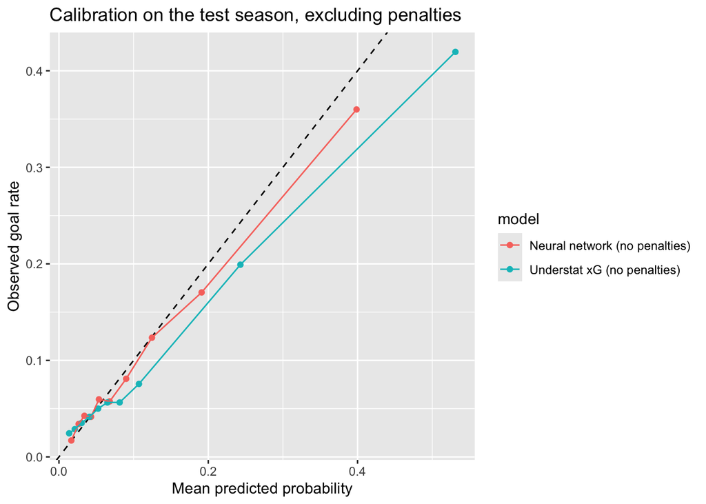

```r
bind_rows(
  calib_df(test$result[no_pen], p_nn[no_pen],    "Neural network (no penalties)"),
  calib_df(test$result[no_pen], test$xg[no_pen], "Understat xG (no penalties)")
) %>%
  ggplot(aes(mean_pred, obs_rate, colour = model)) +
  geom_abline(linetype = "dashed") +
  geom_point() +
  geom_line() +
  labs(x = "Mean predicted probability", y = "Observed goal rate",
       title = "Calibration on the test season, excluding penalties")
```

```r
# Shot types are assigned in order of priority: penalty, set piece, open play.
# If the data has other indicators (for example headers), add them here.
shot_type <- case_when(
  test$is_penalty   == 1 ~ "Penalty",
  test$is_set_piece == 1 ~ "Set piece",
  test$is_open_play == 1 ~ "Open play",
  TRUE                   ~ "Other"
)

map_dfr(unique(shot_type), function(t) {
  i <- shot_type == t
  bind_rows(
    evaluate(test$result[i], p_nn[i],    "Neural network"),
    evaluate(test$result[i], test$xg[i], "Understat xG")
  ) %>%
    mutate(shot_type = t, shots = sum(i), goals = sum(test$result[i]), .before = 1)
}) %>%
  arrange(shot_type, model)
```

```
## # A tibble: 6 × 7
##   shot_type shots goals model          log_loss  brier   auc
##   <chr>     <int> <dbl> <chr>             <dbl>  <dbl> <dbl>
## 1 Open play  6926   700 Neural network    0.278 0.0791 0.769
## 2 Open play  6926   700 Understat xG      0.267 0.0757 0.790
## 3 Penalty      92    77 Neural network    0.432 0.133  0.685
## 4 Penalty      92    77 Understat xG      0.462 0.142  0.487
## 5 Set piece  2465   227 Neural network    0.267 0.0739 0.750
## 6 Set piece  2465   227 Understat xG      0.260 0.0728 0.775
```

### Uncertainty in the comparison with Understat

The differences between the neural network and Understat’s xG are small, so a bootstrap is used to check whether they could be due to chance. On each resample the neural network and Understat are scored on the same shots, and the difference in each metric is recorded. If the test data contains a match identifier (`match_id`, `game_id` or `fixture_id`), whole matches are resampled, which respects the fact that shots from the same match are related. Otherwise individual shots are resampled, which assumes independence and may make the intervals too narrow.

Differences are defined as neural network minus Understat. For log loss and Brier score, a negative difference favours the neural network; for ROC-AUC, a positive difference favours it. An interval that includes 0 means the difference cannot be distinguished from chance. The comparison with the other three models is carried out in the group comparison notebook.

```r
set.seed(2026)
B <- 500
n <- nrow(test)

cluster_col <- intersect(c("match_id", "game_id", "fixture_id"), names(test))[1]
idx_by_cluster <- if (!is.na(cluster_col)) split(seq_len(n), test[[cluster_col]]) else NULL
cat("Resampling unit:", if (is.na(cluster_col)) "individual shots" else paste0("matches (", cluster_col, ")"), "\n")
```

```
## Resampling unit: individual shots
```

```r
diff_metrics <- function(idx) {
  y <- test$result[idx]
  c(log_loss = log_loss(y, p_nn[idx]) - log_loss(y, test$xg[idx]),
    brier    = brier(y, p_nn[idx])    - brier(y, test$xg[idx]),
    auc      = auc(y, p_nn[idx])      - auc(y, test$xg[idx]))
}

boot <- replicate(B, {
  idx <- if (is.null(idx_by_cluster)) {
    sample.int(n, n, replace = TRUE)
  } else {
    unlist(idx_by_cluster[sample.int(length(idx_by_cluster), replace = TRUE)], use.names = FALSE)
  }
  diff_metrics(idx)
})

observed <- diff_metrics(seq_len(n))

tibble(
  metric     = names(observed),
  difference = as.numeric(observed),
  ci_low     = apply(boot, 1, quantile, probs = 0.025),
  ci_high    = apply(boot, 1, quantile, probs = 0.975)
)
```

```
## # A tibble: 3 × 4
##   metric   difference   ci_low  ci_high
##   <chr>         <dbl>    <dbl>    <dbl>
## 1 log_loss    0.00991  0.00551  0.0143
## 2 brier       0.00269  0.00120  0.00408
## 3 auc        -0.0206  -0.0293  -0.0128
```

## 7. Exploration for the performance-metric part of the brief

### 7a. Generalising to unseen shot types

Train only on open-play shots, then test on set-piece shots the network has never seen, versus a network trained on everything. This shows in what sense the metric on the standard test set overstates real-world generalisability. Because `is_open_play` and `is_set_piece` are constant in the open-play training data, the network cannot learn weights for them, so the set-piece test shots are genuinely out of distribution. Note that if penalties are counted as set pieces, they may dominate this comparison.

```r
op_train <- filter(trval, is_open_play == 1)
sp_test  <- filter(test, is_set_piece == 1)

sc_op <- scale_fit(op_train)
m_op  <- fit_nn(to_matrix(op_train, sc_op), op_train$result, best$size, best$decay,
                seeds = 1:5, maxit = 300)  # same seeds and maxit as the final model
p_op  <- predict_nn(m_op, to_matrix(sp_test, sc_op))

p_all <- predict_nn(final_models, to_matrix(sp_test, sc_fin))

bind_rows(evaluate(sp_test$result, p_op,  "Trained on open play only"),
          evaluate(sp_test$result, p_all, "Trained on all shots"),
          evaluate(sp_test$result, sp_test$xg, "Understat xG"))
```

```
## # A tibble: 3 × 4
##   model                     log_loss  brier   auc
##   <chr>                        <dbl>  <dbl> <dbl>
## 1 Trained on open play only    0.313 0.0905 0.727
## 2 Trained on all shots         0.267 0.0739 0.750
## 3 Understat xG                 0.260 0.0728 0.775
```

### 7b. Permutation importance

Shuffle one feature at a time in the test set and record how much log loss increases, averaged over 10 repeated shuffles. Because `x`, `y`, `distance` and `angle_to_goal` are strongly correlated, shuffling one at a time can understate their joint importance.

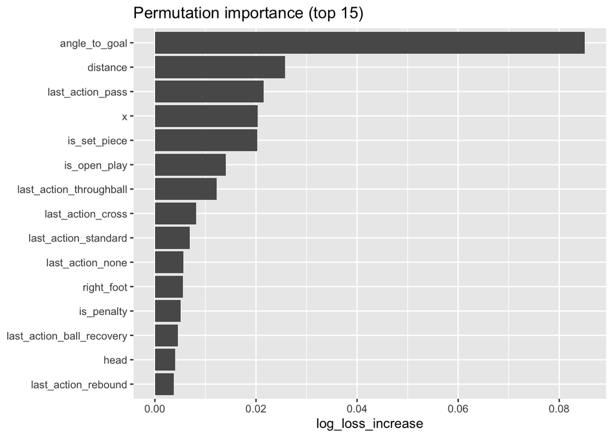

```r
set.seed(2026)
n_rep <- 10
base_ll <- log_loss(test$result, p_nn)
perm_imp <- sapply(feature_cols, function(f) {
  mean(replicate(n_rep, {
    Xp <- X_te
    Xp[, f] <- sample(Xp[, f])
    log_loss(test$result, predict_nn(final_models, Xp)) - base_ll
  }))
})
perm_imp %>% sort(decreasing = TRUE) %>% head(15) %>%
  enframe(name = "feature", value = "log_loss_increase") %>%
  ggplot(aes(reorder(feature, log_loss_increase), log_loss_increase)) +
  geom_col() + coord_flip() + labs(x = NULL, title = "Permutation importance (top 15)")
```

## 8. Conditions for a neural network to work

The neural network used in this analysis is designed to learn non-linear relationships between shot characteristics and the probability of scoring. This is useful for xG modelling because the influence of features such as shot location, distance, angle and shot type may not be straightforward or linear. Unlike a traditional regression model, a neural network can learn more complex relationships and interactions between these features without requiring them to be explicitly specified.

However, the model’s performance depends on the quality and quantity of the training data. Categorical variables must be converted into numerical inputs, missing values must be handled, and continuous variables must be scaled appropriately. The preprocessing in this analysis addresses these requirements, with scaling parameters calculated using the training data only to avoid information leakage.

The model must also be able to generalise to unseen shots. Using a chronological split allows its performance to be assessed on a later season, providing a more realistic evaluation of how it might perform on future data. However, changes in the distribution of shots or playing styles may affect its predictions. The experiment in Section 7a demonstrates this potential limitation by investigating how a network trained exclusively on open-play shots performs on set pieces.

## 9. Advantages and disadvantages of the neural network

The main advantage of the neural network is its ability to model non-linear relationships and interactions between features. This gives it the flexibility to capture complex patterns in shot data that may be more difficult for a traditional regression model to represent. Its probabilistic output is also appropriate for xG modelling, as it assigns each shot a predicted probability of resulting in a goal.

However, this flexibility comes at the cost of interpretability. The network’s weights are difficult to translate into clear explanations of how individual features influence scoring probability. The permutation importance analysis in Section 7b provides some insight into which features the model relies on, although correlated features such as coordinates, distance and angle make individual importance harder to interpret.

The neural network also requires choices about its architecture and training process, including the number of hidden neurons, weight decay and random initialisation. These choices can influence performance and require validation to select suitable settings. In comparison, simpler regression models may be easier to interpret, while random forests and gradient boosting offer alternative ways of capturing non-linear relationships. Therefore, the neural network’s greater flexibility does not necessarily mean it will produce the most accurate xG predictions. Its effectiveness must be judged against the other models using the same test data and evaluation metrics.

## 10. Potential extensions

One potential extension would be to investigate whether different modelling approaches are better suited to different types of shots. The experiment in Section 7a suggests that a network trained on open-play shots may not transfer effectively to set pieces. Separate models could therefore be developed for categories such as penalties, free kicks and open-play shots, following the approach of Kharrat et al. [4]. The same investigation could be applied to the regression, random forest and gradient boosting models to determine whether this pattern is specific to neural networks or common across modelling approaches.

Another extension would be to investigate feature importance more consistently across all four models. This would allow the importance of shot location, distance, angle and shot type to be compared, providing insight into whether the different approaches rely on similar information when estimating scoring probability. For the neural network, grouped permutation importance could be particularly useful because several geometric features are strongly correlated.

Finally, the models could be investigated further in terms of their calibration and performance across different ranges of xG. Although overall metrics provide a useful comparison, they may conceal differences in how accurately the models estimate probabilities for low- and high-quality chances. Examining these differences would help establish not only which model predicts most accurately overall, but also whether its predicted probabilities are reliable across different types of scoring opportunities.

# References

[1]

G. James, D. Witten, T. Hastie, and R. Tibshirani, *An introduction to statistical learning: With applications in r*, 2nd ed. New York: Springer, 2021. doi: 10.1007/978-1-0716-1418-1.

[2]

T. Gneiting and A. E. Raftery, “Strictly proper scoring rules, prediction, and estimation,” *Journal of the American Statistical Association*, vol. 102, no. 477, pp. 359–378, 2007, doi: 10.1198/016214506000001437.

[3]

G. W. Brier, “Verification of forecasts expressed in terms of probability,” *Monthly Weather Review*, vol. 78, no. 1, pp. 1–3, 1950, doi: 10.1175/1520-0493(1950)078<0001:VOFEIT>2.0.CO;2.

[4]

T. Kharrat, J. López Peña, and I. McHale, “Plus-minus player ratings for soccer.” 2017. Available: https://arxiv.org/abs/1706.04943

[5]

J. A. Hanley and B. J. McNeil, “The meaning and use of the area under a receiver operating characteristic (ROC) curve,” *Radiology*, vol. 143, no. 1, pp. 29–36, 1982.

[6]

T. Fawcett, “An introduction to ROC analysis,” *Pattern Recognition Letters*, vol. 27, no. 8, pp. 861–874, 2006, doi: 10.1016/j.patrec.2005.10.010.

[7]

E. W. Steyerberg *et al.*, “Assessing the performance of prediction models: A framework for traditional and novel measures,” *Epidemiology*, vol. 21, no. 1, pp. 128–138, 2010.

[8]

B. Van Calster, D. J. McLernon, M. van Smeden, L. Wynants, and E. W. Steyerberg, “Calibration: The achilles heel of predictive analytics,” *BMC Medicine*, vol. 17, p. 230, 2019, doi: 10.1186/s12916-019-1466-7.

[9]

J. Mead, A. O’Hare, and P. McMenemy, “Expected goals in football: Improving model performance and demonstrating value,” *PLOS ONE*, vol. 18, no. 4, p. e0282295, 2023.

[10]

W. N. Venables and B. D. Ripley, *Modern applied statistics with S*, 4th ed. New York: Springer, 2002.